# A3: Incarceration

### Introduction

An introduction of the problem domain and a description of the variable(s) you are choosing to analyze (and why!)

The problem domain of incarceration in America is a significant issue with a great number of its population behind bars. I’ll be analyzing the total population of people in America incarcerated, comparing the differences between states/counties and how a person’s demographic such as race may play a role as a significant amount of the people behind bars are part of the Black community. I’m analyzing these variables, such as total_prison_pop, total_black_prison_pop, male_prison_pop, female_prison_pop, black_male_prison_pop, black_female_prison_pop to gain insights to potential trends that may be occurring and see if there’s correlation between variables such as race.

### Summary Information

Write a summary paragraph of findings that includes the 5 values calculated from your summary information R script

These will likely be calculated using your DPLYR skills, answering questions such as:

My variable: black_prison_pop

- Which county has the greatest average for my variable?

The greatest county and its average is New York County, 1.9141074^{4}.

- Where is my variable the highest?

It was the highest in New York County.

- Where is my variable the lowest?

It was the lowest in Cleburne County.

- How much has my variable change for the male population over the last N = 10 years in King County, WA?

A difference of 184.

- How much has my variable change for the female population over the last N = 10 years in King County, WA?

Feel free to calculate and report values that you find relevant. Again, remember that the purpose is to think about how these measure of incarceration vary by race.

Summary:

### The Dataset

Who collected the data?

The Vera Institute.

How was the data collected or generated?

This data was generated/provided by the Vera Institute from data that was already collected by the U.S. Department of Justice Bureau of Justice Statistics(BJS) which covers all jails and is collected every 5-8 years, the Death in Custody Reporting Program (DCRP) which collects data from about 2800 local jails every year since 2000, and the Annual Survey of Jails who covers about 1/3 of jails since 1985.

Why was the data collected?

The data was collected to expose patterns of inequality regarding incarceration injustice that’s influences by variables such as one’s demographic.

How many observations (rows) are in your data?

There are 153811 rows of observations in my data.

How many features (columns) are in the data?

There are 36 features in my data.

What, if any, ethical questions or questions of power do you need to consider when working with this data?

Some potential ethical questions or questions of power we need to consider when working with this data is privacy. Working with incarceration data is sensitive as for example that individual may not want information about their incarceration to be collected in data and shared with the public. Additionally, we should question if bringing things such as demographics such as race or gender may instill stereotypes and have the public react a certain way when said stereotypes aren’t accurate for everyone such as how the Black community contributes to a significant amount of the people in prison doesn’t mean that the majority of Black people are dangerous. Since such idea is influencing the public, when going forward, officers may treat Black people less well just because of their race.

What are possible limitations or problems with this data? (at least 200 words)

Possibly limitations or problems when working with this data could include issues such as not having context or sufficient information about the incarceration. For example, we don’t know the severity of each incarceration. Maybe one was for underage drinking and the other was for a robbery or a worse crime than that. But regardless, we don’t know the extent of the crime and we’re categorizing them all in the same features. My variable was the “black_prison_pop.” So for example, maybe a lot of the incarcerations there were for underage drinking but due to things such as bias from officers, they were more likely to be arrested than maybe a white individual. Since this data is online, there could always be collecting/reporting issues. Whether caused by human error or a glitch in the system, there could be factors that skew the data. In other cases, maybe there was bias when the officer was reporting the case and lied due to their own opinions and views rather than the case itself. For example, if it is a white officer who views Black people as “dangerous,” he’s more likely to exaggerate the severity of the case if he is arresting a black male.

### Trends Over Time Chart

Include a chart. Make sure to describe why you included the chart, and what patterns emerged

The first chart that you will create and include will show the trend over time of your variable/topic. Think carefully about what you want to communicate to your user (you may have to find relevant trends in the dataset first!). Here are some requirements to help guide your design:

- Show more than one, but fewer than ~10 trends
  - This may mean showing the same measure for different locations or different racial groups. Think carefully about a meaningful comparison of locations (e.g., the top 10 counties in a state, top 10 states, etc.)
- You must have clear x and y axis labels
- The chart needs a clear title
- You need a legend for your different line colors and a clear legend title

When we say “clear” or “human readable” titles and labels, that means that you should not just display the variable name.

Here’s an example of how to run an R script inside an RMarkdown file:

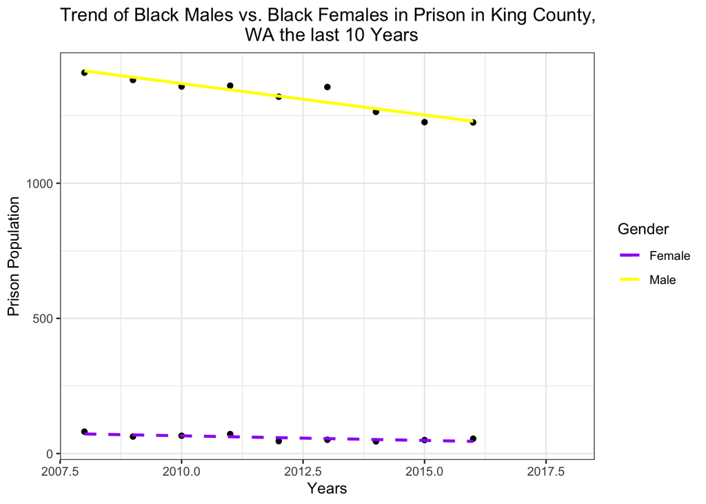

### Variable Comparison Chart

Include a chart. Make sure to describe why you included the chart, and what patterns emerged

The second chart that you will create and include will show how two different (continuous) variables are related to one another. Again, think carefully about what such a comparison means and what you want to communicate to your user (you may have to find relevant trends in the dataset first!). Here are some requirements to help guide your design:

- You must have clear x and y axis labels
- The chart needs a clear title
- If you choose to add a color encoding (not required), you need a legend for your different color and a clear legend title

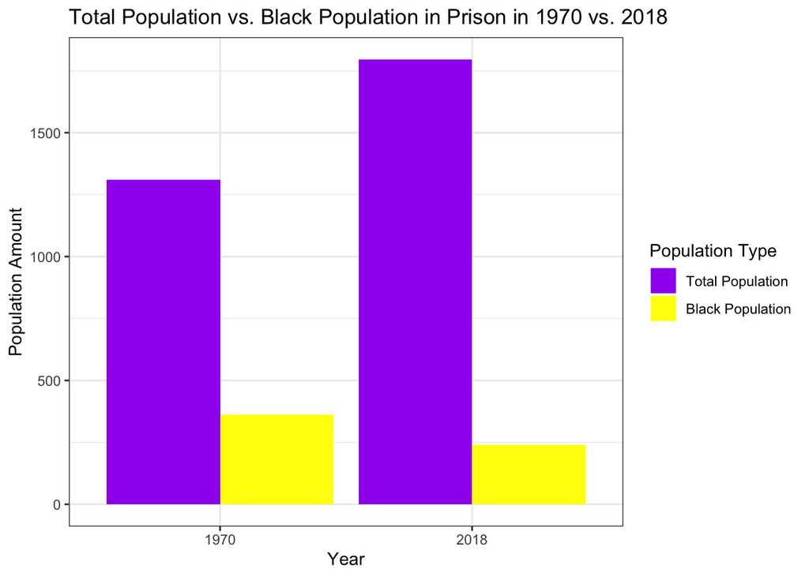

I included this double grouped bar graph because I wanted to compare how many people of the Black community are being incarcerated compared to the total number of people being incarcerated and compare if that amount has decreased over the years. My result shows that the total amount of people being incarcerated has increased in 2018 from 1970 which is a bad thing but the number of Black people incarcerated has in fact decreased which is a good thing. We also see that in 1970, the total amount of Black people in prison makes up about a quarter if the total amount of poeple in prison whereas in 2018, they make up around 1/8 of the total. The values I included in my graph were the total number of people incarcerated in 1970 and 2018 and the total number of Black people in prison in those same years.

### Map

Include a chart. Make sure to describe why you included the chart, and what patterns emerged

The last chart that you will create and include will show how a variable is distributed geographically. Again, think carefully about what such a comparison means and what you want to communicate to your user (you may have to find relevant trends in the dataset first!). Here are some requirements to help guide your design:

- Your map needs a title
- Your color scale needs a legend with a clear label
- Use a map based coordinate system to set the aspect ratio of your map

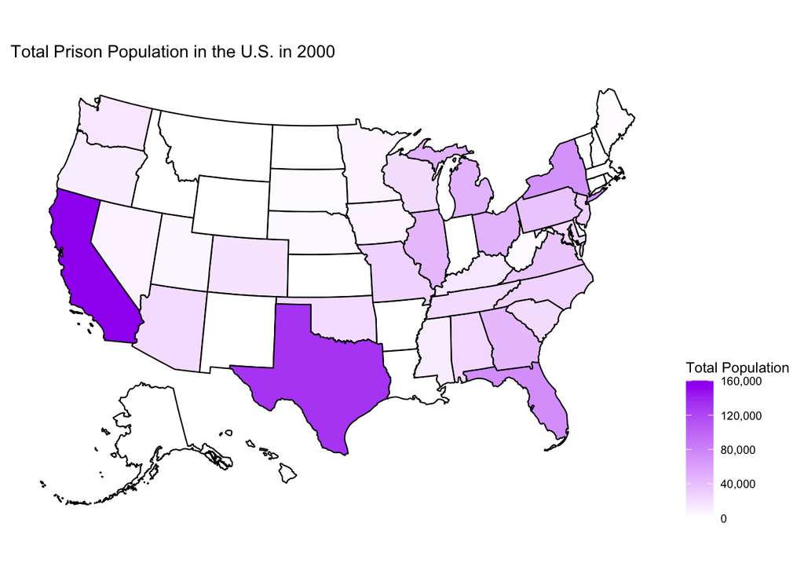